# Seasonal Plots

```r
library(tidyverse)
library(feasts)
library(fpp2)
library(tsibbledata)
theme_set(theme_minimal())
```

1. If our data have seasonal structure, it’s natural to compare individual periods against one another. In contrast to plotting the data in one long time series, seasonal plots reduce the amount of distance our eyes have to travel in order to compare two periods in a seasonal pattern. This also reduces the burden on our memory.
2. In R, we can use the `gg_season` function from the `feasts` package (standing for “Feature Extraction And Statistics (for) Time Series”) to overlay all the seasons onto one another. The plot below shows antidiabetes drug sales over time. This view makes it clear that there is a spike in sales every January.

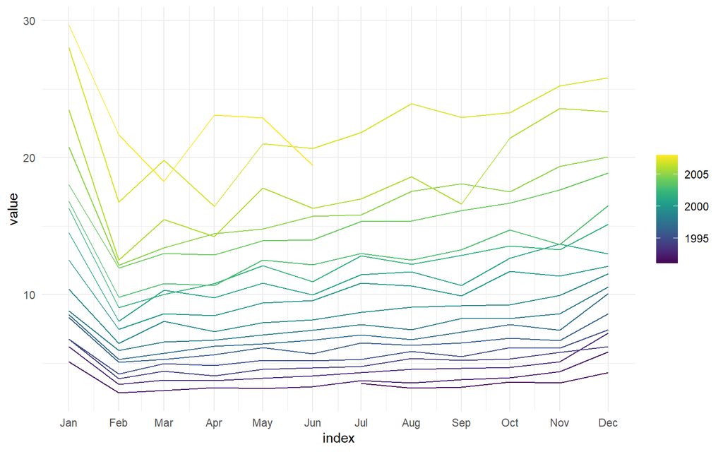

```r
cols <- scales::viridis_pal()(10)
gg_season(as_tsibble(a10), pal = cols)
```

3. If the time series exhibit seasonal structure at multiple scales, then we can view them all using the `period` argument.

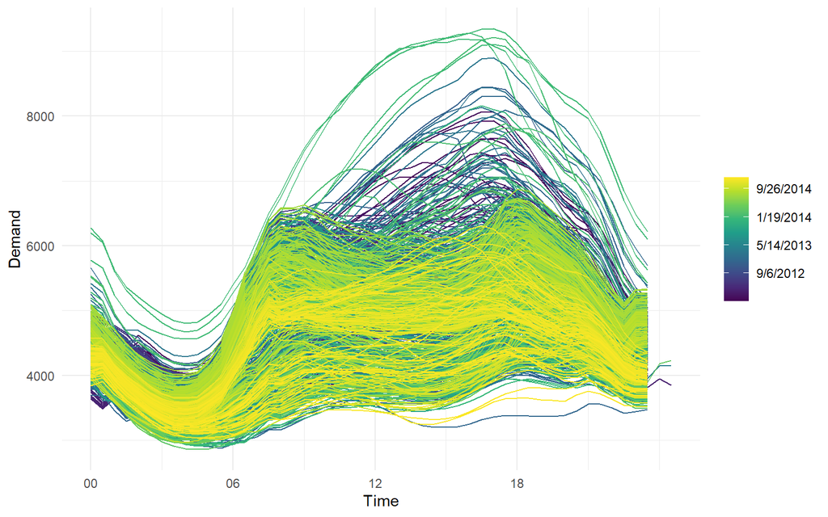

```r
gg_season(vic_elec, Demand, period = "day", pal = cols)
```

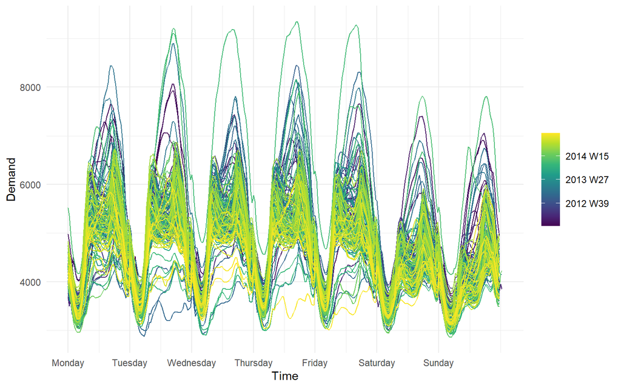

```r
gg_season(vic_elec, Demand, period = "week", pal = cols)
```

4. Notice how `gg_season` streamlines what you might produce with standard `ggplot2` code; it does a reasonable job with the labels, and creates a continuous legend instead of a discrete one like `ggplot2` might default to.
5. `gg_season` also faciltates more specific partitions of your data, like this plot of every 8-hour period in `vic_elec` below. `gg_season` accepts strings like “3h” for 3 hours or “2d” for every 2 days. This would be very difficult/tedious to make with `dplyr` and `ggplot2`. (*Of course, such plots are only useful if you have prior reason to suspect such a trend in your data, which we don’t here with electricity usage.*)

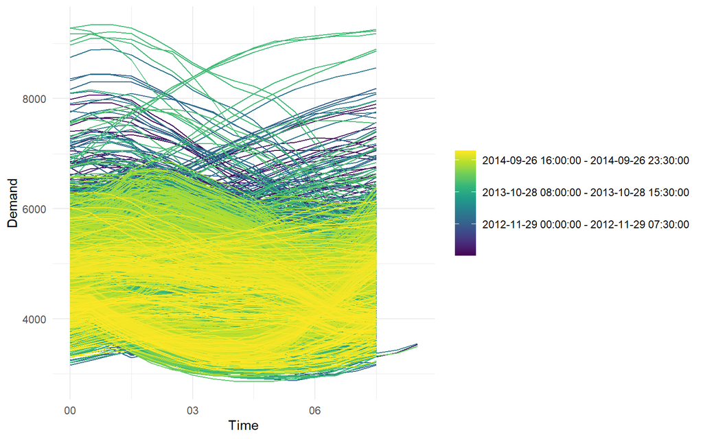

```r
gg_season(vic_elec, Demand, period = "8h", pal = cols)
```